# R Mini Project 3: R Script Covering Outliers and Graphs

Thinh Le

2024-10-18

# Background

The original data were collected and made available by Dr. Kristen Gorman and the Palmer Station, Antarctica LTER, a member of the Long Term Ecological Research Network. However, we added a few “**dirty**” data points to make this project more interesting. The data are observations of Antarctic penguins (Genus Pygoscelis). You can read more about the actual dataset at https://doi.org/10.1371/journal.pone.0090081. The dataset contains size measurements for three different species of penguins, collected from three islands in the Palmer Archipelago, Antarctica.

If you do not like penguins or whales or dolphins (come on! Everyone likes dolphins!! 👏), you can pretend the data are on three different aircrafts or patients or anything. This application applies to any situation where you are asked to explore a dataset with quantitative measurements on three different types of items. In this specific case, they are penguins.

# Instructions

Write an R script with inline comments that successfully:

- Write your name, date, and assignment at the top
- Loads all necessary libraries
- Reads in the data
- Describes the data using:
  - At a minimum – glimpse() and summary() and document anything you think significant from the results
  - Other unique ways to explore and describe the data are encouraged.
- Explores and cleans the data:
  - Check for NAs or blanks. Take appropriate action to address the missing values, and document whatever action you take. This includes if you choose to take no action.
  - Explore the various columns of data by graphing or some statistical method, such as range() or summary(). Document any outliers.
  - The year column is read in as a number/integer. Correct any outliers, which may be typos, if you reasonably believe you know what the year should be. Document what you do. Also document if you leave the year as an integer or change it to a datetime field. If you change it, include your reason for changing it.
  - Change the columns or create new columns from species, island, and sex to be factors.
  - Using ggplot(), graph different combinations of the variables/columns. If you notice an outlier, take the appropriate action and document what you did, including leaving it as-is.
  - Create some graphs to visualize data by one of the factors (i.e. by species, island, or sex). Document your interpretation of what you find.
- Save the new cleaned data frame as a new .csv file named “penguins_alt_YourLastName.csv”

# Solution

## Loads libraries

```r
# Load the libraries
library(dplyr)     # Working with data frames
library(lubridate) # Working with date & time
library(stringr)   # Working with strings
library(ggplot2)   # Working with graphs
library(tidyr)     # Working with data
```

## Reads the data

```r
# Read the data, must be in the same folder with the source file
penguin_df <- read.csv("penguins_alt.csv")
```

## Describes the data

### Views a glimpse of data

```r
# Use glimpse() to view the structure of the data
glimpse(penguin_df)
```

```
Rows: 348
Columns: 9
$ rowid             <int> 1, 2, 3, 4, 5, 6, 7, 8, 9, 10, 11, 12, 13, 14, 15, 16, 17, 18, 19, 20, 21, 22, 23, 24, 25, 26, 27, 28, 29, 30…
$ species           <chr> "Adelie", "Adelie", "Adelie", "Adelie", "Adelie", "Adelie", "Adelie", "Adelie", "Adelie", "Adelie", "Adelie",…
$ island            <chr> "Torgersen", "Torgersen", "Torgersen", "Torgersen", "Torgersen", "Torgersen", "Torgersen", "Torgersen", "Torg…
$ bill_length_mm    <dbl> 39.1, 39.5, 40.3, NA, 36.7, 39.3, 38.9, 39.2, 34.1, 42.0, 37.8, 37.8, 41.1, 38.6, 34.6, 36.6, 38.7, 42.5, 34.…
$ bill_depth_mm     <dbl> 18.7, 17.4, 18.0, NA, 19.3, 20.6, 17.8, 19.6, 18.1, 20.2, 17.1, 17.3, 17.6, 21.2, 21.1, 17.8, 19.0, 20.7, 18.…
$ flipper_length_mm <int> 181, 186, 195, NA, 193, 190, 181, 195, 193, 190, 186, 180, 182, 191, 198, 185, 195, 197, 184, 194, 174, 180, …
$ body_mass_g       <int> 3750, 3800, 3250, NA, 3450, 3650, 3625, 4675, 3475, 4250, 3300, 3700, 3200, 3800, 4400, 3700, 3450, 4500, 332…
$ sex               <chr> "male", "female", "female", NA, "female", "male", "female", "male", NA, NA, NA, NA, "female", "male", "male",…
$ year              <int> 2007, 2007, 2007, 2007, 2007, 2007, 2007, 2007, 2007, 2007, 2007, 2007, 2007, 2007, 2007, 2007, 2007, 2007, 2…
```

### Views data summary

```r
# View data summary
summary(penguin_df)
```

```
     rowid          species             island          bill_length_mm  bill_depth_mm   flipper_length_mm  body_mass_g
 Min.   :  1.00   Length:348         Length:348         Min.   : 0.00   Min.   : 0.00   Min.   :  0.0     Min.   :   0
 1st Qu.: 87.75   Class :character   Class :character   1st Qu.:39.23   1st Qu.:15.53   1st Qu.:190.0     1st Qu.:3550
 Median :174.50   Mode  :character   Mode  :character   Median :44.50   Median :17.30   Median :197.0     Median :4050
 Mean   :174.50                                         Mean   :43.84   Mean   :17.11   Mean   :200.3     Mean   :4180
 3rd Qu.:261.25                                         3rd Qu.:48.50   3rd Qu.:18.70   3rd Qu.:213.0     3rd Qu.:4750
 Max.   :348.00                                         Max.   :59.60   Max.   :21.60   Max.   :231.0     Max.   :6300
                                                        NA's   :2       NA's   :2       NA's   :2         NA's   :2
     sex                 year
 Length:348         Min.   : 209
 Class :character   1st Qu.:2007
 Mode  :character   Median :2008
                    Mean   :2003
                    3rd Qu.:2009
                    Max.   :2070
```

I can see that the dataset contains some outliers, such as zeros in the length and depth of the penguins’ bills, as well as in the length of their flippers and body mass. Besides, there are also NAs exist in the dataset. 🐧

### Views data dimension

```r
# View data dimension
dim(penguin_df)
```

```
[1] 348   9
```

There are 348 rows and 9 columns.

### Views the column names

```r
# View the column names
colnames(penguin_df)
```

```
[1] "rowid"             "species"           "island"            "bill_length_mm"    "bill_depth_mm"     "flipper_length_mm"
[7] "body_mass_g"       "sex"               "year"
```

Almost the column names are beautiful, I will rename the column “rowid” to “row_id” to follow the name pattern.

```r
penguin_df <- penguin_df %>%
  rename(
    "row_id"      = rowid
  )
```

### View the top 10 rows

```r
# View the first 10 rows
head(penguin_df, n = 10)
```

|  | row_id | species | island | bill_length_mm | bill_depth_mm | flipper_length_mm | body_mass_g | sex | year |
| --- | --- | --- | --- | --- | --- | --- | --- | --- | --- |
| 1 | 1 | Adelie | Torgersen | 39.1 | 18.7 | 181 | 3750 | male | 2007 |
| 2 | 2 | Adelie | Torgersen | 39.5 | 17.4 | 186 | 3800 | female | 2007 |
| 3 | 3 | Adelie | Torgersen | 40.3 | 18.0 | 195 | 3250 | female | 2007 |
| 4 | 4 | Adelie | Torgersen | NA | NA | NA | NA | NA | 2007 |
| 5 | 5 | Adelie | Torgersen | 36.7 | 19.3 | 193 | 3450 | female | 2007 |
| 6 | 6 | Adelie | Torgersen | 39.3 | 20.6 | 190 | 3650 | male | 2007 |
| 7 | 7 | Adelie | Torgersen | 38.9 | 17.8 | 181 | 3625 | female | 2007 |
| 8 | 8 | Adelie | Torgersen | 39.2 | 19.6 | 195 | 4675 | male | 2007 |
| 9 | 9 | Adelie | Torgersen | 34.1 | 18.1 | 193 | 3475 | NA | 2007 |
| 10 | 10 | Adelie | Torgersen | 42.0 | 20.2 | 190 | 4250 | NA | 2007 |

Oops, found some records with missing values. 🤨

### View the last 10 rows

```r
# View the last 10 rows
tail(penguin_df, n = 10)
```

|  | row_id | species | island | bill_length_mm | bill_depth_mm | flipper_length_mm | body_mass_g | sex | year |
| --- | --- | --- | --- | --- | --- | --- | --- | --- | --- |
| 339 | 339 | Chinstrap | Dream | 45.7 | 17.0 | 195 | 3650 | female | 2009 |
| 340 | 340 | Chinstrap | Dream | 55.8 | 19.8 | 207 | 4000 | male | 2009 |
| 341 | 341 | Chinstrap | Dream | 43.5 | 18.1 | 202 | 3400 | female | 2009 |
| 342 | 342 | Chinstrap | Dream | 49.6 | 18.2 | 193 | 3775 | male | 2009 |
| 343 | 343 | Chinstrap | Dream | 50.8 | 19.0 | 210 | 4100 | male | 2009 |
| 344 | 344 | Chinstrap | Dream | 50.2 | 18.7 | 198 | 3775 | female | 209 |
| 345 | 345 | Adelie | Torgersen | 46.1 | 21.6 | 193 | 0 | female | 2007 |
| 346 | 346 | Chinstrap | Dream | 49.3 | 18.1 | 195 | 4405 | male | 2070 |
| 347 | 347 | Gentoo | Biscoe | 0.0 | 0.0 | 0 | 0 | male | 2008 |
| 348 | 348 | Gentooo | Biscoe | 50.6 | 15.3 | 215 | 5005 | female | 2009 |

I found many records with bad data. For example, the lengths, depth and body mass are zero, the years are listed as 209 or 2070, and there seems to be a problem with the species names in the column: “Gentoo” and “Gentoo**o**” Hmm… 🥸

Let’s see unique species:

```r
# Check for unique values in the species column
unique(penguin_df$species)
```

```
[1] "Adelie"    "Gentoo"    "Chinstrap" "Gentooo"
```

I can conclude that “Gentoo**o**” is a typo because there was no information of Gentooo species on the website provided. 😬

## Explores and cleans the data

### Checks for NAs or blanks.

Collect all rows having NAs or blanks:

```r
# Search for NAs and blanks from the data frame
penguin_df[!complete.cases(penguin_df), ]
```

|  | row_id | species | island | bill_length_mm | bill_depth_mm | flipper_length_mm | body_mass_g | sex | year |
| --- | --- | --- | --- | --- | --- | --- | --- | --- | --- |
| 4 | 4 | Adelie | Torgersen | NA | NA | NA | NA | NA | 2007 |
| 9 | 9 | Adelie | Torgersen | 34.1 | 18.1 | 193 | 3475 | NA | 2007 |
| 10 | 10 | Adelie | Torgersen | 42.0 | 20.2 | 190 | 4250 | NA | 2007 |
| 11 | 11 | Adelie | Torgersen | 37.8 | 17.1 | 186 | 3300 | NA | 2007 |
| 12 | 12 | Adelie | Torgersen | 37.8 | 17.3 | 180 | 3700 | NA | 2007 |
| 48 | 48 | Adelie | Dream | 37.5 | 18.9 | 179 | 2975 | NA | 2007 |
| 179 | 179 | Gentoo | Biscoe | 44.5 | 14.3 | 216 | 4100 | NA | 2007 |
| 219 | 219 | Gentoo | Biscoe | 46.2 | 14.4 | 214 | 4650 | NA | 2008 |
| 257 | 257 | Gentoo | Biscoe | 47.3 | 13.8 | 216 | 4725 | NA | 2009 |
| 269 | 269 | Gentoo | Biscoe | 44.5 | 15.7 | 217 | 4875 | NA | 2009 |

[output cut: 1 more lines]

There are **11**/348 rows having missing (NA) or blank values.

### Takes appropriate action to address the missing values

I think that if all the information about the bill, flipper, and body mass is missing (NA), then I must remove those records. However, if the only missing information is the sex, I believe I can predict it based on the bill, flipper, and body mass of a single penguin.

First, let’s filter out the penguins that not missing bill, flipper, and body mass info.

```r
# Filter out the penguins that not missing bill, flipper, and body mass info
penguin_df <- penguin_df %>%
  filter(
    !is.na(bill_length_mm), !is.na(bill_depth_mm),
    !is.na(flipper_length_mm),
    !is.na(body_mass_g),
  )
```

Now check again for NAs and blanks.

```r
# Search for NAs and blanks from the data frame
penguin_df[!complete.cases(penguin_df), ]
```

|  | row_id | species | island | bill_length_mm | bill_depth_mm | flipper_length_mm | body_mass_g | sex | year |
| --- | --- | --- | --- | --- | --- | --- | --- | --- | --- |
| 8 | 9 | Adelie | Torgersen | 34.1 | 18.1 | 193 | 3475 | NA | 2007 |
| 9 | 10 | Adelie | Torgersen | 42.0 | 20.2 | 190 | 4250 | NA | 2007 |
| 10 | 11 | Adelie | Torgersen | 37.8 | 17.1 | 186 | 3300 | NA | 2007 |
| 11 | 12 | Adelie | Torgersen | 37.8 | 17.3 | 180 | 3700 | NA | 2007 |
| 47 | 48 | Adelie | Dream | 37.5 | 18.9 | 179 | 2975 | NA | 2007 |
| 178 | 179 | Gentoo | Biscoe | 44.5 | 14.3 | 216 | 4100 | NA | 2007 |
| 218 | 219 | Gentoo | Biscoe | 46.2 | 14.4 | 214 | 4650 | NA | 2008 |
| 256 | 257 | Gentoo | Biscoe | 47.3 | 13.8 | 216 | 4725 | NA | 2009 |
| 268 | 269 | Gentoo | Biscoe | 44.5 | 15.7 | 217 | 4875 | NA | 2009 |

Good! we only have 9 penguins missing sex info.

#### Find info on the provided website to make prediction

I must somehow find a connection on the dataset’s website to help with my prediction. I can see with my own eyes that only the Adelie and Gentoo penguins are missing the sex information. Let’s try searching to see if we can find something useful.

From the websites, I found that:

> Adélie penguin **body mass** and **culmen length** are the strongest predictors of sex, while **body mass** and **culmen depth** are the best predictors of male and female Gentoo penguins.

Nice 🥳, I think this is exactly what I’m looking for.

#### Fix the typo issue in the species column

But before continue, I must fix the typo in species column from “Gentoo**o**” to “Gentoo” because it will contribute to my data analysis later:

```r
# Replace Gentooo by Gentoo in the species column
penguin_df$species <- str_replace(penguin_df$species, "Gentooo", "Gentoo")
```

Let’s take a quick look again on the unique values in the species column:

```r
# Check for unique values in the species column
unique(penguin_df$species)
```

```
[1] "Adelie"    "Gentoo"    "Chinstrap"
```

#### Calculate the average values bill length, bill depth and body mass based on species, sex and year

Great! Now I can continue 😄. I will filter the penguins that already have sex information, group them by species (Adélie and Gentoo), as well as by sex and year. Then, I will calculate the average thresholds for body mass, culmen length, and culmen depth for each species.

```r
# Group penguins by species, sex and year
penguins_by_species_sex_year <- penguin_df %>%
  filter(species == "Adelie" | species == "Gentoo", !is.na(sex)) %>%
  group_by(species, year, sex) %>%
  summarise(
    average_bill_length = round(mean(bill_length_mm), digits = 2),
    average_bill_depth = round(mean(bill_depth_mm), digits = 2),
    average_body_mass = round(mean(body_mass_g), digits = 2)
  )
penguins_by_species_sex_year
```

| species | year | sex | average_bill_length | average_bill_depth | average_body_mass |
| --- | --- | --- | --- | --- | --- |
| Adelie | 2007 | female | 38.28 | 18.28 | 3242.39 |
| Adelie | 2007 | male | 39.95 | 19.51 | 4038.64 |
| Adelie | 2008 | female | 36.52 | 17.46 | 3386.00 |
| Adelie | 2008 | male | 40.60 | 18.92 | 4098.00 |
| Adelie | 2009 | female | 37.41 | 17.35 | 3334.62 |
| Adelie | 2009 | male | 40.56 | 18.85 | 3995.19 |
| Gentoo | 2007 | female | 45.06 | 13.99 | 4618.75 |
| Gentoo | 2007 | male | 49.00 | 15.36 | 5552.94 |
| Gentoo | 2008 | female | 45.30 | 14.13 | 4627.27 |
| Gentoo | 2008 | male | 46.52 | 15.05 | 5185.42 |

[output cut: 2 more lines]

Since the difference between body mass and bill length/depth is two big, I will plot several bar charts for us to visualize the numbers:

#### Bar charts of average bill length of Adélie penguins by sex in 2007:

*Note: because bill length is not a factor to predict sex of Gentoo penguins, and we only care the year 2007 because the missing sex values of Adélie penguins are in this year.*

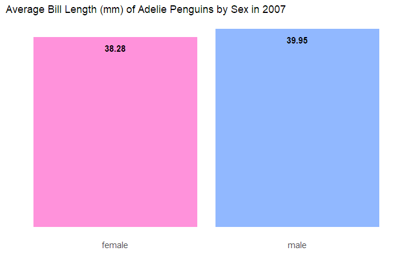

```r
penguins_by_average_bill_length <- penguins_by_species_sex_year %>%
  filter(
    species == "Adelie",
    year == 2007
  )

ggplot(
  penguins_by_average_bill_length,
  aes(x = sex, y = average_bill_length, fill = sex)
) +
  # Apply no statistic and 'dodge' puts bars side by side
  geom_bar(stat = "identity", position = "dodge") +
  # Add average numbers near the top of each column
  geom_text(
    aes(label = average_bill_length),
    position = position_dodge(width = 0.9),
    vjust = 2,
    fontface = "bold",
    size = 4,
    color = "black"
  ) +
  scale_fill_manual(values = c(
      "female" = "#FF92DB",
      "male" = "#91B8FF"
    )
  ) +
  labs(
    title = "Average Bill Length (mm) of Adelie Penguins by Sex in 2007"
  ) +
  # Adjust theme for a better look
  theme_classic() +
  theme(
    legend.position = "none",
    axis.title = element_blank(),
    axis.text.x = element_text(size = 11),
    axis.text.y = element_blank(),
    axis.line = element_blank(),
    axis.ticks = element_blank()
  )
```

Adelie penguins with a bill length from 39.95 mm or above are likely male.

#### Bar charts of average bill depth of Gentoo penguins by sex and year from 2008 to 2009:

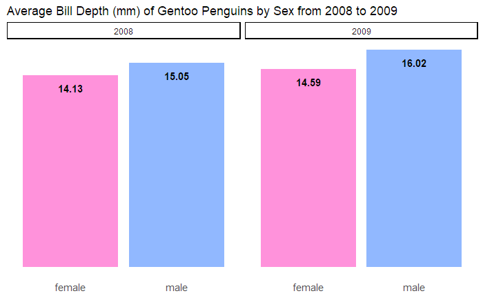

```r
penguins_by_average_bill_depth <- penguins_by_species_sex_year %>%
  filter(
    species == "Gentoo",
    2008 <= year, year <= 2009
  )

ggplot(
  penguins_by_average_bill_depth,
  aes(x = sex, y = average_bill_depth, fill = sex)
) +
  # Apply no statistic and 'dodge' puts bars side by side
  geom_bar(stat = "identity", position = "dodge") +
  # Add average numbers near the top of each column
  geom_text(
    aes(label = average_bill_depth),
    position = position_dodge(width = 0.9),
    vjust = 2,
    fontface = "bold",
    size = 4,
    color = "black"
  ) +
  scale_fill_manual(values = c(
      "female" = "#FF92DB",
      "male" = "#91B8FF"
    )
  ) +
  # Split view by year
  facet_wrap(~year) +
  labs(
    title = "Average Bill Depth (mm) of Gentoo Penguins by Sex from 2008 to 2009"
  ) +
  # Adjust theme for a better look
  theme_classic() +
  theme(
    legend.position = "none",
    axis.title = element_blank(),
    axis.text.x = element_text(size = 11),
    axis.text.y = element_blank(),
    axis.line = element_blank(),
    axis.ticks = element_blank()
  )
```

Gentoo penguins are likely male when their bill depth is 15.05 mm or greater in 2008, and 16.02 mm or greater in 2009.

#### Bar charts of average body mass of Adelie and Gentoo penguins by sex and year:

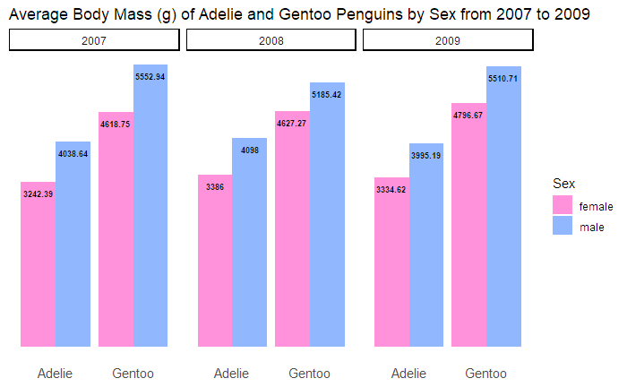

```r
ggplot(
  penguins_by_species_sex_year,
  aes(x = species, y = average_body_mass, fill = sex)
) +
  # Apply no statistic and 'dodge' puts bars side by side
  geom_bar(stat = "identity", position = "dodge") +
  # Add average numbers near the top of each column
  geom_text(
    aes(label = average_body_mass),
    position = position_dodge(width = 0.9),
    vjust = 2,
    fontface = "bold",
    size = 2.5,
    color = "black"
  ) +
  scale_fill_manual(values = c(
      "female" = "#FF92DB",
      "male" = "#91B8FF"
    )
  ) +
  # Split view by year
  facet_wrap(~year) +
  labs(
    title = "Average Body Mass (g) of Adelie and Gentoo Penguins by Sex from 2007 to 2009",
    fill = "Sex"
  ) +
  # Adjust theme for a better look
  theme_classic() +
  theme(
    axis.title = element_blank(),
    axis.text.x = element_text(size = 11),
    axis.text.y = element_blank(),
    axis.line = element_blank(),
    axis.ticks = element_blank()
  )
```

In 2007, Adelie penguins with body mass from 4038.64 g or above, are likely male.

Gentoo penguins are likely male when their body mass is 5185.42 g or greater in 2008, and 5510.71 mm or greater in 2009.

To summarize this:

- For Adelie penguins:
  - In 2007, if the body mass is from **4038.64 g or above** and the bill length is from **39.95 mm or above**, they are are likely male.
- For Gentoo penguins:
  - In 2008, if the body mass is from **5185.42 g or above** and the bill depth is from **15.05 mm or above**, they are are likely male.
  - In 2009, if the body mass is from **5510.71 g or above** and the bill depth is from **16.02 mm or above**, they are are likely male.

#### Fill in NA values in the sex column with the data collected

Alright, so I had something to make my prediction, let’s fill in the data for the missing sex values.

```r
penguin_df <- penguin_df %>%
  mutate(sex = case_when(
    # Adélie penguins in 2007: Predict male if body mass >= 4038.64 and bill length >= 39.95
    species == "Adelie" & year == 2007 & is.na(sex) & body_mass_g >= 4038.64 & bill_length_mm >= 39.95 ~ "male",
    # Gentoo penguins in 2008: Predict male if body mass >= 5185.42 and bill depth >= 15.05
    species == "Gentoo" & year == 2008 & is.na(sex) & body_mass_g >= 5185.42 & bill_depth_mm >= 15.05 ~ "male",
    # Gentoo penguins in 2009: Predict male if body mass >= 5510.71 and bill depth >= 16.02
    species == "Gentoo" & year == 2009 & is.na(sex) & body_mass_g >= 5510.71 & bill_depth_mm >= 16.02 ~ "male",
    # If no condition is met assign sex = "female"
    is.na(sex) ~ "female",
    # Keep existing values for other cases
    TRUE ~ sex
  ))
```

Let’s check if we still have NA values in the data frame

```r
# Search for NAs and blanks from the data frame
penguin_df[!complete.cases(penguin_df), ]
```

| row_id | species | island | bill_length_mm | bill_depth_mm | flipper_length_mm | body_mass_g | sex | year |
| --- | --- | --- | --- | --- | --- | --- | --- | --- |

0 rows, perfect! 😁

## Explore the various columns of data by graphing or some statistical method and document any outliers.

### Species column

```r
# Check for unique values in the species column
unique(penguin_df$species)
```

```
[1] "Adelie"    "Gentoo"    "Chinstrap"
```

### Island column

```r
# Check for unique values in the island column
unique(penguin_df$island)
```

```
[1] "Torgersen" "Biscoe"    "Dream"
```

### Sex column

```r
# Check for unique values in the sex column
unique(penguin_df$sex)
```

```
[1] "male"   "female"
```

### Year column

```r
# Summarize the year column
summary(penguin_df$year)
```

```
   Min. 1st Qu.  Median    Mean 3rd Qu.    Max.
    209    2007    2008    2003    2009    2070
```

### Measurement columns

```r
# Summarize the bill length, bill depth, flipper length and body mass columns
summary(penguin_df$bill_length_mm)
```

```
   Min. 1st Qu.  Median    Mean 3rd Qu.    Max.
   0.00   39.23   44.50   43.84   48.50   59.60
```

```r
summary(penguin_df$bill_depth_mm)
```

```
   Min. 1st Qu.  Median    Mean 3rd Qu.    Max.
   0.00   15.53   17.30   17.11   18.70   21.60
```

```r
summary(penguin_df$flipper_length_mm)
```

```
   Min. 1st Qu.  Median    Mean 3rd Qu.    Max.
    0.0   190.0   197.0   200.3   213.0   231.0
```

```r
summary(penguin_df$body_mass_g)
```

```
   Min. 1st Qu.  Median    Mean 3rd Qu.    Max.
      0    3550    4050    4180    4750    6300
```

I will filter out rows with zeros in those columns:

```r
penguin_df <- penguin_df %>%
  filter(
    bill_length_mm > 0, bill_depth_mm > 0,
    flipper_length_mm > 0,
    body_mass_g > 0,
  )
```

```r
# Summarize the bill length, bill depth, flipper length and body mass columns
summary(penguin_df$bill_length_mm)
```

```
   Min. 1st Qu.  Median    Mean 3rd Qu.    Max.
  32.10   39.27   44.50   43.96   48.52   59.60
```

```r
summary(penguin_df$bill_depth_mm)
```

```
   Min. 1st Qu.  Median    Mean 3rd Qu.    Max.
  13.10   15.57   17.30   17.15   18.70   21.50
```

```r
summary(penguin_df$flipper_length_mm)
```

```
   Min. 1st Qu.  Median    Mean 3rd Qu.    Max.
  172.0   190.0   197.0   200.9   213.2   231.0
```

```r
summary(penguin_df$body_mass_g)
```

```
   Min. 1st Qu.  Median    Mean 3rd Qu.    Max.
   2700    3550    4050    4205    4756    6300
```

Ok, this is better.

## Correct any outliers in the year column

Years in 209 or 2070 are weird to me. The year range should be from 2007 to 2009. Let’s fix this by change from 209 to 2009 and 2070 to 2007.

```r
penguin_df <- penguin_df %>%
  mutate(year = case_when(
    # 209 -> 2009
    year == 209 ~ 2009,
    # 2070 -> 2007
    year == 2070 ~ 2007,
    # Keep existing values for other cases
    TRUE ~ year
  ))
```

Alright, now check again:

```r
# Get the year range
range(penguin_df$year)
```

```
[1] 2007 2009
```

Looks better now.

Finally, I will convert the year value to integer to for plotting data purpose.

```r
penguin_df$year <- as.integer(penguin_df$year)
```

## Change the columns or create new columns from species, island, and sex to be factors

```r
# Modify species, island, and sex columns to be factors
penguin_df$species <- as.factor(penguin_df$species)
penguin_df$island <- as.factor(penguin_df$island)
penguin_df$sex <- as.factor(penguin_df$sex)
```

## Graph different combinations of the variables/columns

I have made 3 graphs above to visualize about the average values of bill length, bill depth and body mass by species, sex and year. I will try with a new scenario.

### Flipper length by year

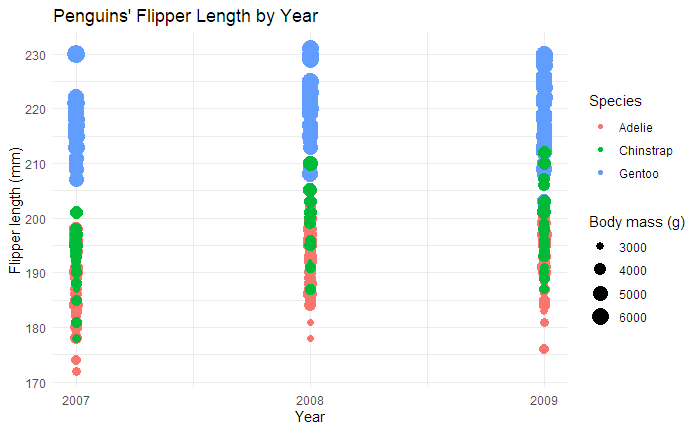

```r
ggplot(penguin_df, aes(x = year, y = flipper_length_mm, size = body_mass_g)) +
  geom_point(aes(color = species)) +
  labs(
    title = "Penguins' Flipper Length by Year",
    x = "Year",
    y = "Flipper length (mm)",
    size = "Body mass (g)",
    color = "Species"
  ) +
  # Scale the year
  scale_x_continuous(breaks = seq(min(penguin_df$year), max(penguin_df$year))) +
  theme_minimal()
```

The chart shows a combination of species, flipper length and body mass by year.

We can easily see that Gentoo species have the biggest flipper length among others. 🐧🐧🐧

## Visualize data by one of the factors (i.e. by species, island, or sex)

### Distribution of species by island

I’m still curious about the distribution of species by island 🤔, let’s visualize that.

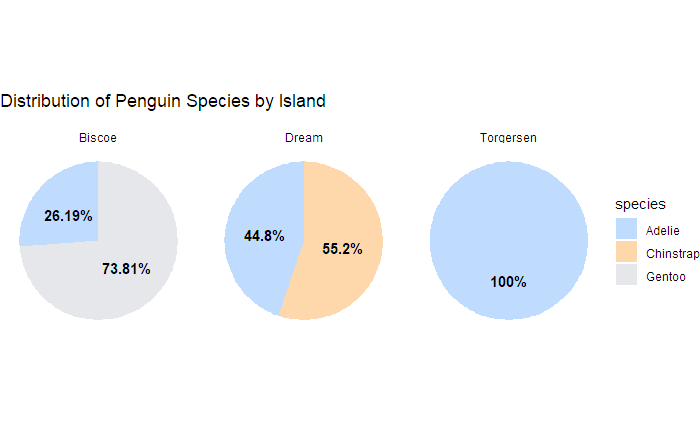

```r
penguins_by_island_and_species <- penguin_df %>%
  group_by(island, species) %>%
  summarise(count = n()) %>%
  mutate(rate = count / sum(count) * 100)
ggplot(penguins_by_island_and_species, aes(x = "", y = rate, fill = species)) +
  geom_bar(stat = "identity", width = 1) +
  # Convert bar chart to pie chart
  coord_polar("y") +
  # Add rate in the corresponding area
  geom_text(
    aes(
      label = paste0(round(rate, digits = 2), "%")
    ),
    position = position_stack(vjust = 0.5),
    fontface = "bold"
  ) +
  scale_fill_manual(values = c(
    "Adelie" = "#bfdbfe",
    "Chinstrap" = "#fed7aa",
    "Gentoo" = "#e5e7eb")
  ) +
  facet_wrap(~ island) +  # Facet by island
  labs(
    title = "Distribution of Penguin Species by Island",
    x = NULL,
    y = NULL
  ) +
  theme_void() +  # Remove axis text and gridlines
  theme(
    plot.title = element_text(margin = margin(b = 15))
  )
```

Wow! 😲 Torgersen island has only Adelie penguins. But why there is no island has three species stay together.. 🤔

### Flipper length by Sex from 2007 to 2009

Let’s draw a box plot to see this relationship:

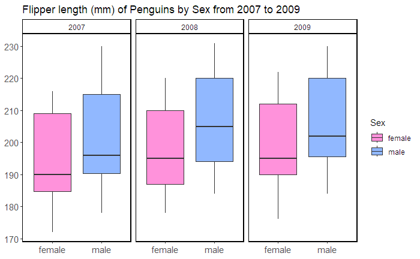

```r
ggplot(
  penguin_df,
  aes(x = sex, y = flipper_length_mm, fill = sex)
) +
  # Apply no statistic and 'dodge' puts bars side by side
  geom_boxplot() +
  scale_fill_manual(values = c(
      "female" = "#FF92DB",
      "male" = "#91B8FF"
    )
  ) +
  # Split view by year
  facet_wrap(~year) +
  labs(
    title = "Flipper length (mm) of Penguins by Sex from 2007 to 2009",
    fill = "Sex"
  ) +
  # Adjust theme for a better look
  theme_classic() +
  theme(
    axis.title = element_blank(),
    axis.text.x = element_text(size = 11),
    axis.text.y = element_text(size = 11),
    panel.border = element_rect(color = "black", fill = NA, linewidth = 1)
  )
```

Well, it seem like male penguins have longer flipper than female penguins.

## Pictures

I want to collect some images of penguins by species 😎

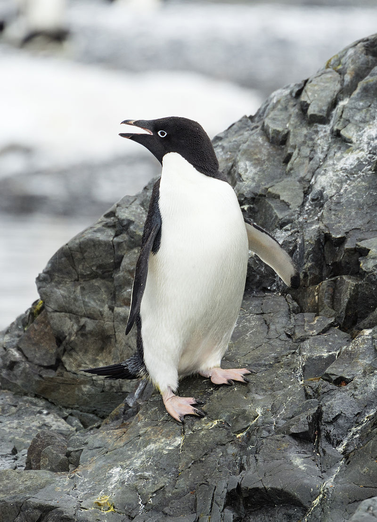

Adelie penguin

[figure not shown]

Chinstrap penguin

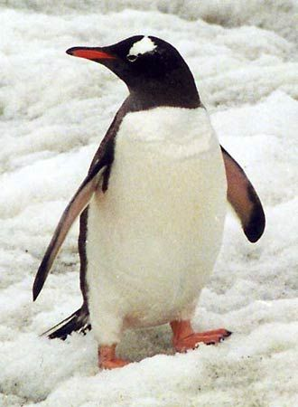

Gentoo penguin

Amazing! They really don’t look like each other at all. 🤓

## Save the new cleaned data frame as a new .csv file named “penguins_alt_YourLastName.csv”

```r
# Create a new file in the current working directory
write.csv(penguin_df, "penguins_alt_Le.csv")
```